# Assignment Week 1

### Name: H.C. (Bram) Otten

### ULCN: s2330326

# EXERCISE I. Simulating from the triangular distribution

The *triangular distribution* is the three-parameter family of distributions with probability density looking like this:

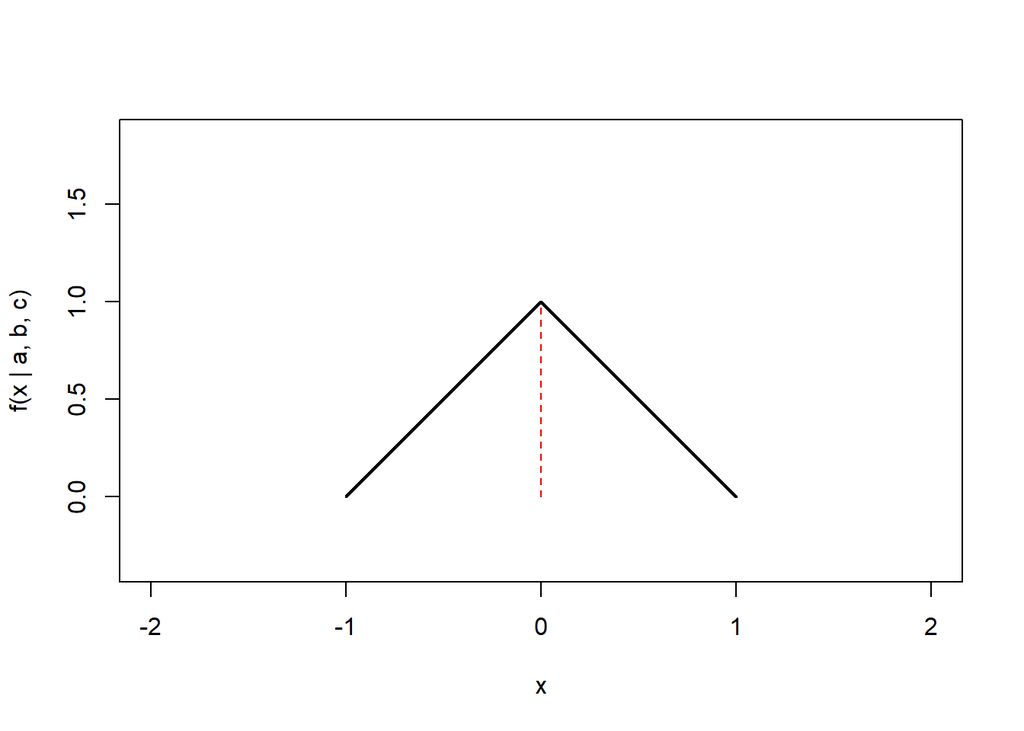

The three parameters $a$, $b$ and $c$ define the $x$ values at the left, right and top position of the triangle, respectively. In this assignment we focus on the symmetric case $c = \frac{1}{2}(a + b)$ and even more in particular, the case $a = -1, b = +1, c= 0$ which we will call the standard symmetrical triangular distribution.

### (a) Derivation of cdf.

Derive the cumulative distribution function $F$ of the standard triangular distribution, and the quantile function $Q$.

In the plot, we see density

$$f(x) =
\begin{cases}
0 &\text{if } x < -1;\\
1-|x|=1+x &\text{if } -1 \leq x \leq 0;\\
1-|x|=1-x &\text{if } 0 < x \leq 1;\\
0 &\text{if } x > 1.
\end{cases}$$

Which must be integrated (with a common sense $\frac{1}{2}$ added) for cumulative

$$F(x) =
\begin{cases}
0 &\text{if } x < -1;\\
\int_{-1}^x(1+x)dx=\frac{(1+x)^2}{2} &\text{if } -1 \leq x \leq 0;\\
\frac{1}{2} + \int_0^x(1-x)dx=1-\frac{(1-x)^2}{2} &\text{if } 0 < x \leq 1;\\
1 &\text{if } x > 1.
\end{cases}$$

Quantile function $Q$ returns an $x$ below which a proportion $p$ of draws from $F$ would fall. So $Q: [0,1] \to [-1, 1]$ and $Q(p) = F^{-1}(p)$.

Let’s start with $x \in [-1, 0]$. $p=\frac{(1+x)^2}{2} \implies x=\pm\sqrt{2p}-1,$ but only the positive version works with the values $p$ can take on. The story is similar for $x \in [0, 1]$ – we must again take into account the values $x$ and $p$ can take on for

$$Q(p) =
\begin{cases}
-1+\sqrt{2p} &\text{if } 0 \leq p \leq \frac{1}{2};\\
1-\sqrt{2-2p} &\text{if } \frac{1}{2} \leq p \leq 1.
\end{cases}$$

### (b) Draw sample.

Write R functions to generate a random sample of size $n$ from the standard triangular distribution;

1. using the trick that the sum of the two independent uniforms has a triangular distribution,

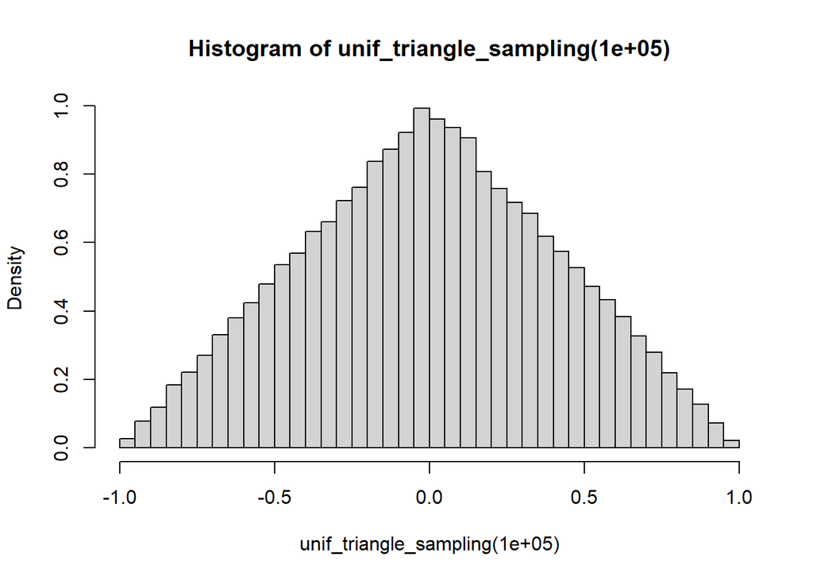

```r
unif_triangle_sampling <- function(n)
  runif(n, min = -1, max = 0) + runif(n, min = 0, max = 1)
hist(unif_triangle_sampling(10e4), breaks = 50, freq = FALSE)
```

2. using the inverse transform method,

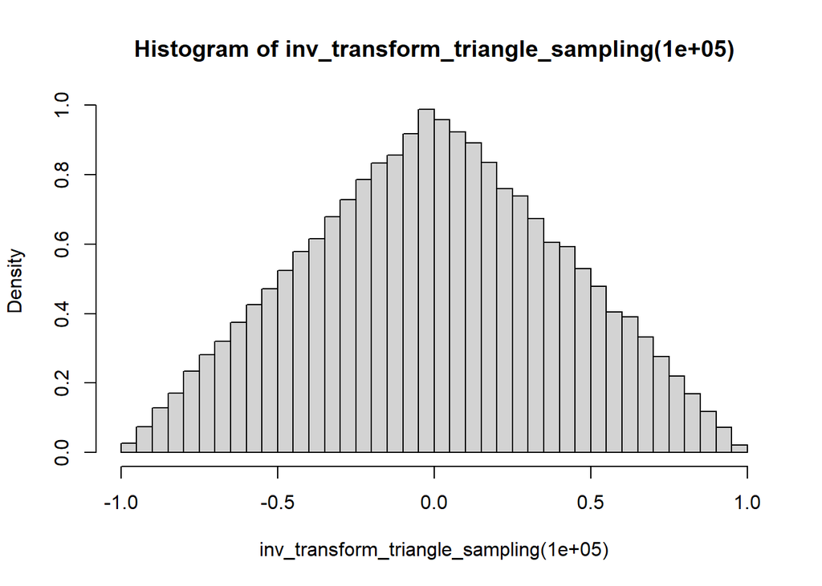

```r
triangle_quantile <- function(p)
  if (p <= 0.5) -1 + sqrt(2 * p) else 1 - sqrt(2 - 2 * p)

inv_transform_triangle_sampling <- function(n)
  sapply(runif(n, min = 0, max = 1), triangle_quantile)
hist(inv_transform_triangle_sampling(10e4), breaks = 50, freq = FALSE)
```

3. using the acceptance-rejection method (*cf. Rizzo Example 3.7*),

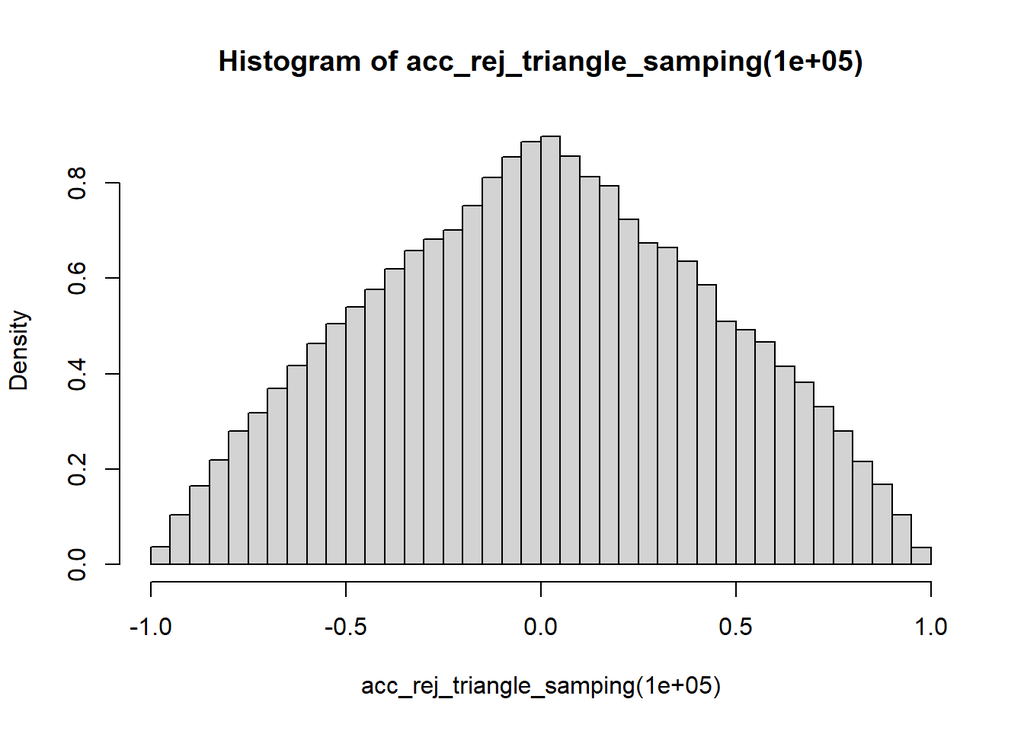

```r
triangle_density <- function(x) { return(1 - abs(x)) }

acc_rej_triangle_samping <- function(n) {
  g <- dnorm
  m <- sqrt(2 * pi)  # x = 0 in both cases

  n_samples <- 0
  # total_n <- 0
  z <- numeric(n)
  while (n_samples < n) {
    # total_n <- total_n + 1
    x <- runif(1, min = -1, max = 1)  # sample from g
    u <- runif(1)
    y <- m * u * g(x)
    if (y <= triangle_density(x)) {
      n_samples <- n_samples + 1
      z[n_samples] <- x
    }
  }
  # print(total_n)
  z
}
hist(acc_rej_triangle_samping(10e4), breaks = 50, freq = FALSE)
```

4. and last, use the functions `system.time()` and `replicate()` to compare the efficiency of these methods.

```r
system.time(replicate(20, unif_triangle_sampling(20e3)))
```

```
##    user  system elapsed
##    0.06    0.00    0.07
```

```r
system.time(replicate(20, inv_transform_triangle_sampling(20e3)))
```

```
##    user  system elapsed
##    0.66    0.00    0.66
```

```r
system.time(replicate(20, acc_rej_triangle_samping(20e3)))
```

```
##    user  system elapsed
##    7.32    0.01    7.40
```

Sampling from the uniform is clearly most efficient, but consists of a trick that is not generally applicable. The inverse transform method works relatively well too, but required a quantile function. The acceptance-rejection method may be slowest, but it only required a density function and my choice for the standard normal as $g$ is a bit dubious – in the order of half the samples from it are rejected.

# EXERCISE II. Mixtures of Gaussians

$X$, $Y$ and $Z$ are independent, and normally distributed with variance 1; their means are $-1$, $1$ and $0$ respectively. Now define the following two additional random variables:

- $U = (X+Y)/2$
- $V = \begin{cases} X&\text{if $Z<0$, and}\\ Y&\text{otherwise}. \end{cases}$

### (a) Plot histograms

Generate a random sample from the distribution of $U$, and plot a histogram using the function `hist`. Do the same for the distribution of $V$.

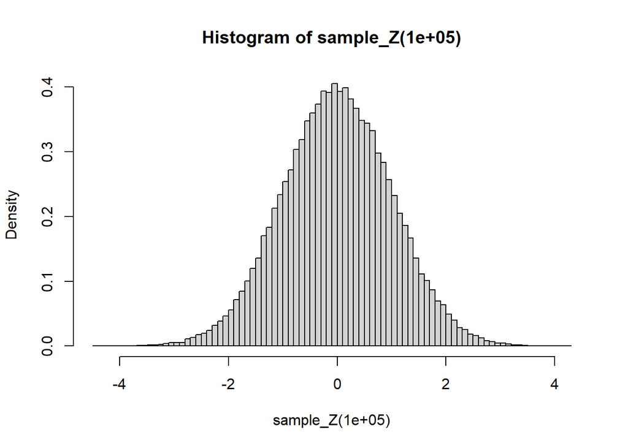

```r
sample_X <- function(n) rnorm(n, mean = -1, sd = 1)
sample_Y <- function(n) rnorm(n, mean = 1, sd = 1)
sample_Z <- function(n) rnorm(n, mean = 0, sd = 1)
hist(sample_Z(10e4), breaks = 100, freq = FALSE)  # for reference
```

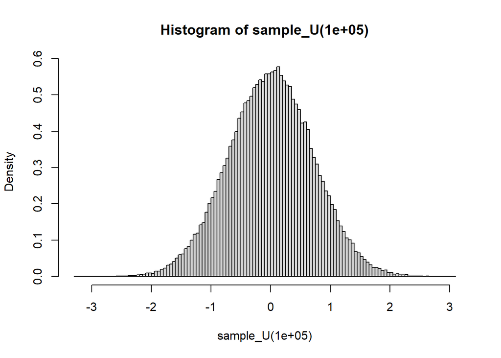

```r
sample_U <- function(n) (sample_X(n) + sample_Y(n)) / 2
hist(sample_U(10e4), breaks = 100, freq = FALSE)  # less variance
```

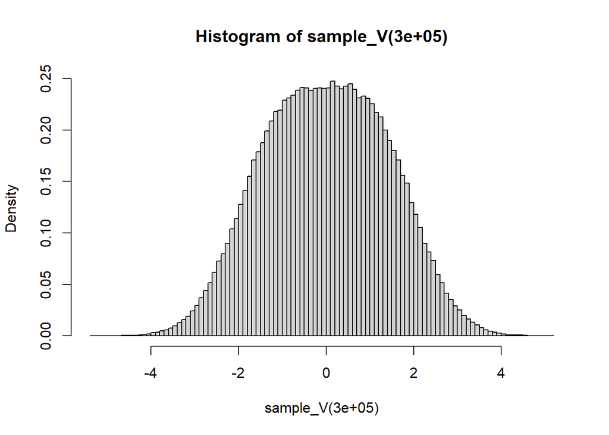

```r
sample_V <- function(n) ifelse(sample_Z(n) < 0, sample_X(n), sample_Y(n))
# (This is not the first time I'm surprised at how R works.)
hist(sample_V(30e4), breaks = 100, freq = FALSE)
```

```r
# (More samples because more variance)
```

### (b) What about the distributions?

- Write down the densities of $U$ and $V$.

The density of $V$ sort of follows from its definition:

$$f_V(v) = F_Z(v)f_X(v) + (1-F_Z(v))f_Y(v).$$
* Which of these densities is bimodal (has multiple local maxima)?

$V$ is bimodal (although it’s hard to see without a bigger difference in means or smaller variances). All other random variables are normal.

- Which of these densities describes a mixture of the distributions of $X$ and $Y$?

$V$, both with weights 0.5.

- What distribution is described by the other density?